# NexText

Text Prediction Widget

Paul Ringsted

8th March 2019

## Methodology: Dictionary and N-Gram Processing

The objective of this project is to create a text prediction model/algorithm and shiny application - **NexText** - to perform text prediction, using a “corpus” of 3 documents as a source for training data - extracts from blogs, news and twitter.

Following is the pre-processing methodology used to construct the N-gram model used in NexText:

[output not shown]

Note: stopwords were included in the dictionary and N-grams. The code was written to remove stopwords to analyze this option, but not found to be beneficial.

## Methodology: Dictionary & N-Gram Statistics

The following chart shows the CDF curve for the corpus coverage by features (unique words) in the corpus. It shows the 50%, 90% and 95% quantiles, with 95% coverage at 20205 words:

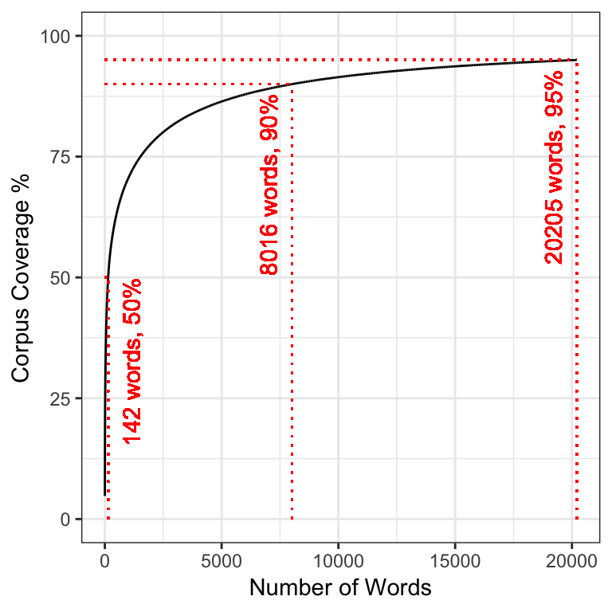

The following table shows the N-gram statistics during pre-processing, with reduction of volume from 167.2 million N-grams to 8.8 million, by removing N-grams which only occurred once, and taking the top 5 most likely N-gram outcomes for each prefix.

| N-gram Length | Valid N-Grams | Freq > 1 | Freq > 1 & Rank <=5 |
| --- | --- | --- | --- |
| 1 | 20,205 | 20,205 | 5 |
| 2 | 8,593,694 | 3,301,886 | 100,877 |
| 3 | 35,572,136 | 6,780,307 | 2,790,315 |
| 4 | 57,632,798 | 5,045,820 | 3,658,156 |
| 5 | 65,368,173 | 2,430,379 | 2,201,968 |
| Total | 167,187,006 | 17,578,597 | 8,751,321 |

## Methodology: Prediction Function

The function **ng_predict_app()** takes a phrase and returns either a list of predictions (to support benchmarking), or grid of the full prediction data (used by the shiny app). The function assumes the dictionary and N-gram data tables are already loaded. The steps are as follows:

[output not shown]

Examples:

```r
ng_predict_app("and a case of",choices=8)               # choices > 0 returns table
```

```
##    next_word ngram_len ngram_freq ngram_prob ngram_prob_rank
## 1:      beer         5          4    0.36364               1
## 2:       the         4         92    0.20309               1
## 3:      beer         4         22    0.04857               2
## 4:  mistaken         4         13    0.02870               3
## 5:         a         4         11    0.02428               4
## 6:      wine         4          7    0.01545               5
## 7:       the         3        464    0.21723               1
## 8:         a         3        209    0.09785               2
```

```r
ng_predict_app("from the bottom of my",choices=-3)      # choices < 0 returns list of next_word only
```

```
## [1] "heart" "feet"  "foot"
```

## NexText App

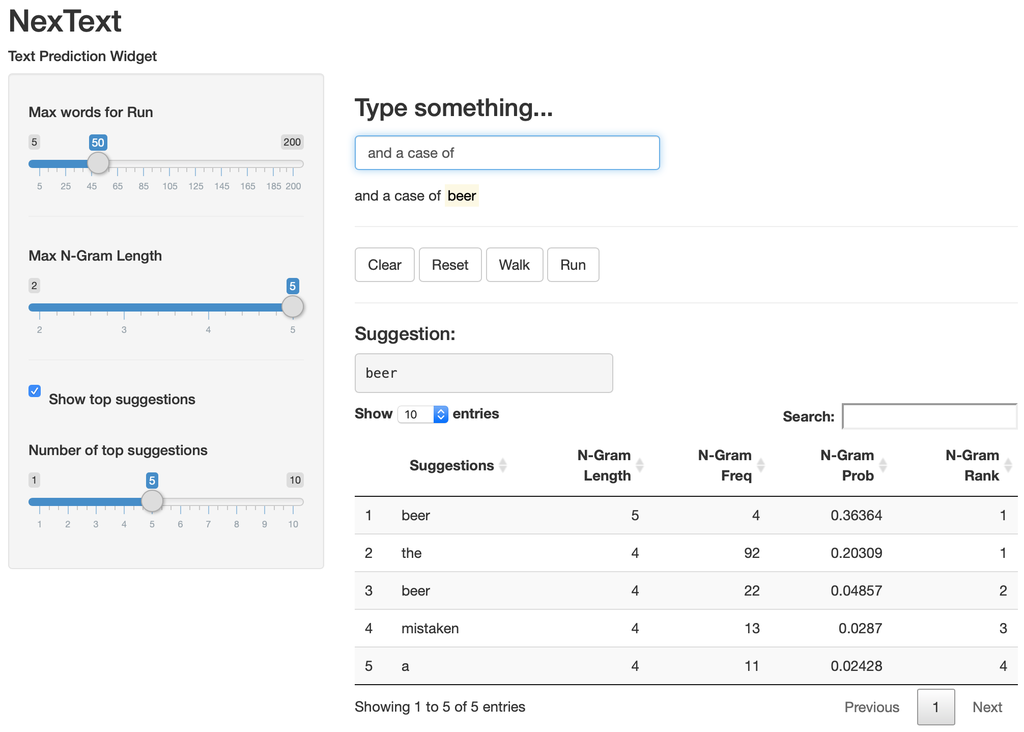

Typing a phrase automatically generates a prediction and adds it to a display of the complete sentence.

Clicking **Walk** will accept the current top prediction and get the next prediction (keep clicking Walk to extend the sentence).

Clicking a suggestion in the grid will use that word instead of the top prediction, and get the next prediction.

Clicking **Run** will automatically generate words, up to the maximum number of words set by the slider on the left.

## NexText App Functionality

The following further describes the parameters and functionality available to the user (Help tab is provided in the app):

| Parameter/Function | Description |
| --- | --- |
| Max Words for Run | Maximum sentence length to generate after clicking Run |
| Max N-Gram Length | Maximum N-Gram length to include in prediction. Higher N provides more accuracy and coherence |
| Show Top Suggestions | Whether to show the top suggestion grid. Automatically turned off during a Run sequence for performance |
| Number of Top Suggestions | How many suggestions from the prediction to display, or use during the random selection in a Run sequence |
| Clear | Clear input box to start over, leave parameters unchanged |
| Reset | Clear input box to start over, reset parameters to default values |
| Walk | Run the prediction and append the top choice word to the input box |
| Run | Loops the prediction with random selection of top specified # of suggestions, up to specified Max Words for Run |

Link to widget:

https://ringspagit.shinyapps.io/NexText/

Link to github:

https://github.com/ringspagit/DS10_Capstone_NLP